```julia
using Piccolo
using Optim
using CairoMakie
using Random
set_theme!(theme_dark())
const ⊗ = kron
```

```
kron (generic function with 38 methods)
```

# Background

There are many different ways to solve an optimization problem! What makes $\texttt{Piccolo.jl}$ special? Under the hood, it solves a direct **trajectory optimization**, which is a state-of-the-art approach from robotics 🤖 with a number of **key advantages**, like

✅ Flexible problem design

✅ Better global convergence

✅ Minimum time control

✅ ...and more!

$\texttt{Piccolo.jl}$ modernizes quantum optimal control. Plus, the code is completely **open source**, meaning the added flexibility of trajectory optimization is completely at your disposal.

# Overview

In this Notebook, we will find controls to implement a **two qubit gate** a few different ways.

[🎵] [**Piccolo**](https://arxiv.org/abs/2305.03261) will begin and end our notebook to showcase the advantages of **trajectory optimization** 🏆.

[🍇] [**GRAPE**](https://doi.org/10.1016/j.jmr.2011.07.023) optimizes for control variables by cutting waveforms into a bunch of piecewise constant slices. The controls look like staircases, but the stairs can go up and down wildly.

[🦀] [**CRAB**](https://doi.org/10.1088/1361-6633/ac723c) is like GRAPE ⁉️ (at least, in quantum control, it is!) In CRAB, we replace the independent, piecewise constant controls with coefficients that weigh the influence of predetermined smooth shapes.

# Desiging a two qubit gate

Quantum technology is all about entanglement! Let's entangle a pair of qubits. We'll allow them to be controlled individually and via a single coupling term.

```julia
H_drives = [
    PAULIS.X ⊗ PAULIS.I,
    PAULIS.Y ⊗ PAULIS.I,
    PAULIS.I ⊗ PAULIS.X,
    PAULIS.I ⊗ PAULIS.Y,
    PAULIS.X ⊗ PAULIS.X
]

system = QuantumSystem(H_drives)

# Entangling gate
U_goal = GATES.CX

# Timing information (e.g. 20 ns superconducting qubit gate)
T = 50
Δt = 0.4
```

[output not shown]

## Piccolo

A quantum control problem will allow us to optimize the controls for this gate. In quantum control problems, we want to **minimize the infidelity** 📉.

In *Piccolo.jl*, we solve a **trajectory optimization problem**, which looks like $$ \begin{align} \arg \min_{\mathbf{Z}}\quad & |1 - \mathcal{F}(U_T, U_\text{goal})| \\ \nonumber \text{s.t.} \qquad & U_{t+1} = \exp\{- i H(a_t) \Delta t_t \} U_t, \quad \forall\, t \\ \end{align} $$

🎯 The **objective** is the infidelity.

⚛️ The **constraint** is the Schrödinger equation.

📦 $Z$ is the **trajectory**, a container for the unitaries $U_{1:T}$ and the controls $a_{1:T}$ at all of the timesteps. Our optimization problem stores this at `prob.trajectory`, and we can access variables like the controls using `prob.trajectory.a`.

```julia
prob = UnitarySmoothPulseProblem(system, U_goal, T, Δt);
```

[output not shown]

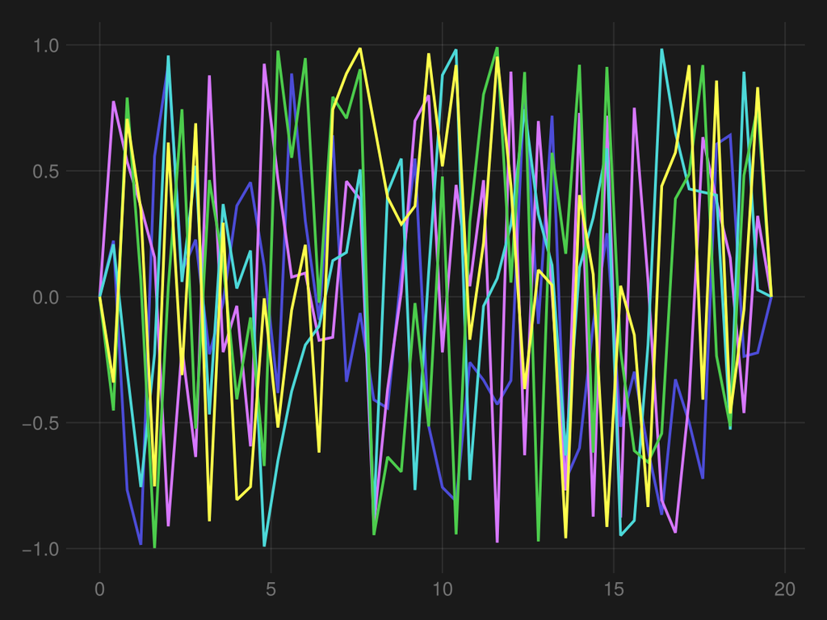

```julia
# save these initial controls for later
a_init = prob.trajectory.a

series(get_times(prob.trajectory), a_init)
```

⚙️ Let's turn the crank and solve! ⚙️

```julia
solve!(prob, max_iter=100, print_level=1)

ℱ = 1 - unitary_rollout_fidelity(prob.trajectory, system)

println("The infidelity is ", 1 - ℱ)
```

```
The infidelity is 0.9947673485951398
```

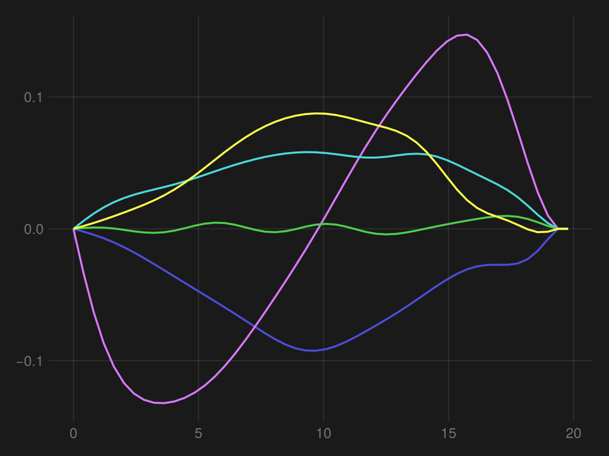

```julia
a_final = prob.trajectory.a

series(get_times(prob.trajectory), a_final)
```

## GRAPE

What about commonly used tools like GRAPE? They solve an optimization problem that looks like $$ \arg \min_{a_{1:T}} \quad 1 - \mathcal{F}(U_T(a_{1:T}), U_{goal}) $$

It's a bit different: this is an **indirect** method, while our approach is a **direct** method. Here, $U_T(a_{1:T})$ is the final state from the **rollout** of the controls on the system.

⚙️ We can use [Optim.jl](https://julianlsolvers.github.io/Optim.jl/stable/) to minimize the **rollout infidelity** with respect to the controls. ⚙️

```julia
timesteps = fill(Δt, T)

GRAPE(controls) = unitary_rollout_fidelity(U_goal, controls, timesteps, system)

result_GRAPE = optimize(GRAPE, a_init, LBFGS(); autodiff = :forward)
```

```
 * Status: success

 * Candidate solution
    Final objective value:     5.061426e-18

 * Found with
    Algorithm:     L-BFGS

 * Convergence measures
    |x - x'|               = 1.60e-06 ≰ 0.0e+00
    |x - x'|/|x'|          = 1.62e-06 ≰ 0.0e+00
    |f(x) - f(x')|         = 1.23e-10 ≰ 0.0e+00
    |f(x) - f(x')|/|f(x')| = 2.42e+07 ≰ 0.0e+00
    |g(x)|                 = 6.20e-10 ≤ 1.0e-08

 * Work counters
    Seconds run:   7  (vs limit Inf)
    Iterations:    4
    f(x) calls:    11
    ∇f(x) calls:   11
```

🚧 ⚠️ You'd be forgiven if you thought we accidentally plotted `a_init` again! It's hard to tell the difference between the initial value and the converged solution. Also, we definitely don't want to hand this over to the scientists and engineers working on the hardware 😬.

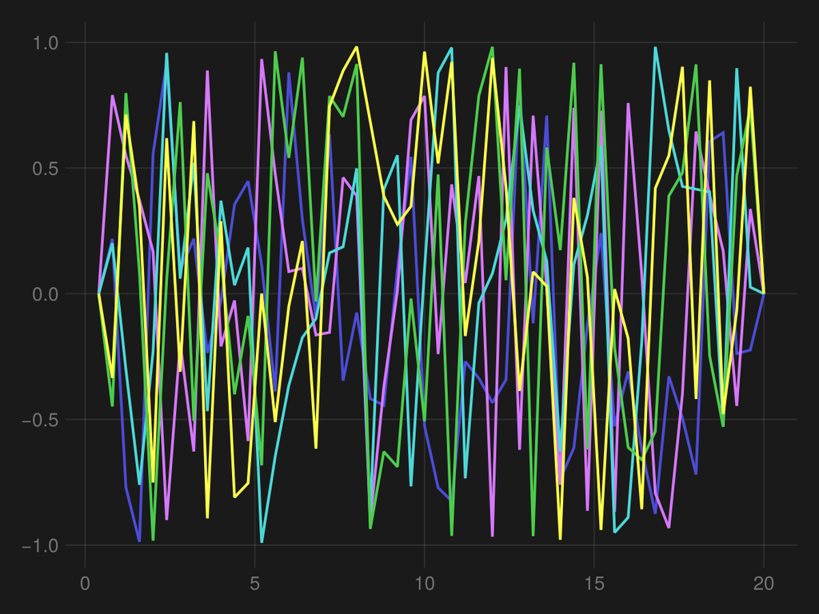

```julia
series(cumsum(timesteps), result_GRAPE.minimizer)
```

## CRAB

A function basis can help. CRAB uses Fourier modes, so we will be true to that. Our optimization parameters are now *coefficients*. $$ a(t) = a_0 + \sum_{j=1}^n c_j a_j(t). $$ During the optimization, the modes $a_j(t)$ stay fixed and the coefficients $c_j$ vary.

```julia
# First n=5 entries in a Fourier series, including the constant term
n = 5
fourier_series = [cos.(π * j * (0:T-1) / T .- π/2) for j in 0:n-1]

function get_controls(coefficients)
    a(c) = sum(cⱼ * aⱼ for (cⱼ, aⱼ) in zip(c, fourier_series))
    return stack([a(c) for c in eachrow(coefficients)], dims=1)
end

function CRAB(coefficients)
    controls = get_controls(coefficients)
    return unitary_rollout_fidelity(U_goal, controls, timesteps, system)
end
```

```
CRAB (generic function with 1 method)
```

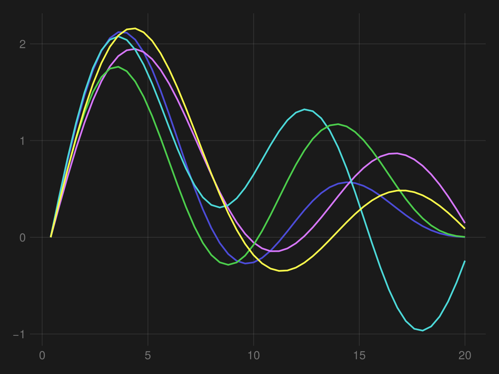

```julia
Random.seed!(1234)
c_init = rand(system.n_drives, n)
result_CRAB = optimize(CRAB, c_init, LBFGS(); autodiff = :forward)

series(cumsum(timesteps), get_controls(result_CRAB.minimizer))
```

🚧 ⚠️ These shapes are a lot nicer! But we're totally beholden to the basis we choose, and we have lost a lot of flexibility! Also, our solution will often depend on the local landscape around our inital guess. We'll get a different result each time!

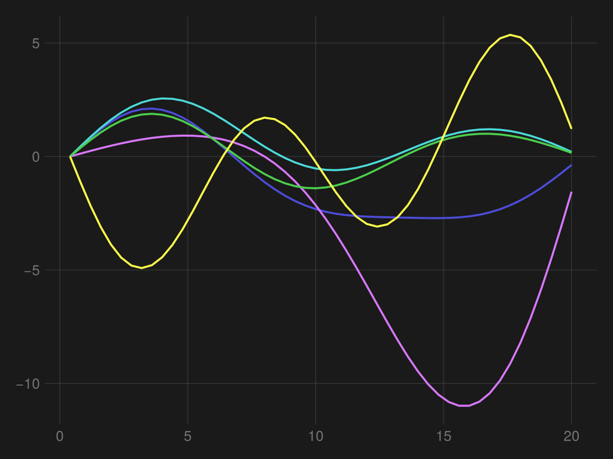

```julia
Random.seed!(5678)
c_init = randn(system.n_drives, n)
result_CRAB = optimize(CRAB, c_init, LBFGS(); autodiff = :forward)
series(cumsum(timesteps), get_controls(result_CRAB.minimizer))
```

## Fine-tuned Quantum Control with $\texttt{Piccolo.jl}$

### Flexible designs

Why does flexibility matter? Well, what if we have very specific bounds on the control hardware? We could try to encode those into a specific basis, or we could just **directly ask for what we want** with $\texttt{Piccolo.jl}$!

```julia
bound_prob = UnitarySmoothPulseProblem(
    system, U_goal, T, Δt,
    a_bound = 0.3,
    da_bound = 0.015
)

solve!(bound_prob, max_iter=100, print_level=1)

ℱ = 1 - unitary_rollout_fidelity(bound_prob.trajectory, system)

println("The infidelity is ", 1 - ℱ)
```

```
    building dynamics from integrators...
        constructing knot point dynamics functions...
        constructing full dynamics derivative functions...
    building evaluator...
    initializing optimizer...
        applying constraint: initial value of Ũ⃗
        applying constraint: initial value of a
        applying constraint: final value of a
        applying constraint: bounds on a
        applying constraint: bounds on da
        applying constraint: bounds on dda
        applying constraint: bounds on Δt
        applying constraint: time step all equal constraint
    finished.
The infidelity is 0.9971485277577704
```

👍 Piccolo has no trouble desiging the solution, but CRAB would require a lot of Fourier modes, or a very carefully designed basis.

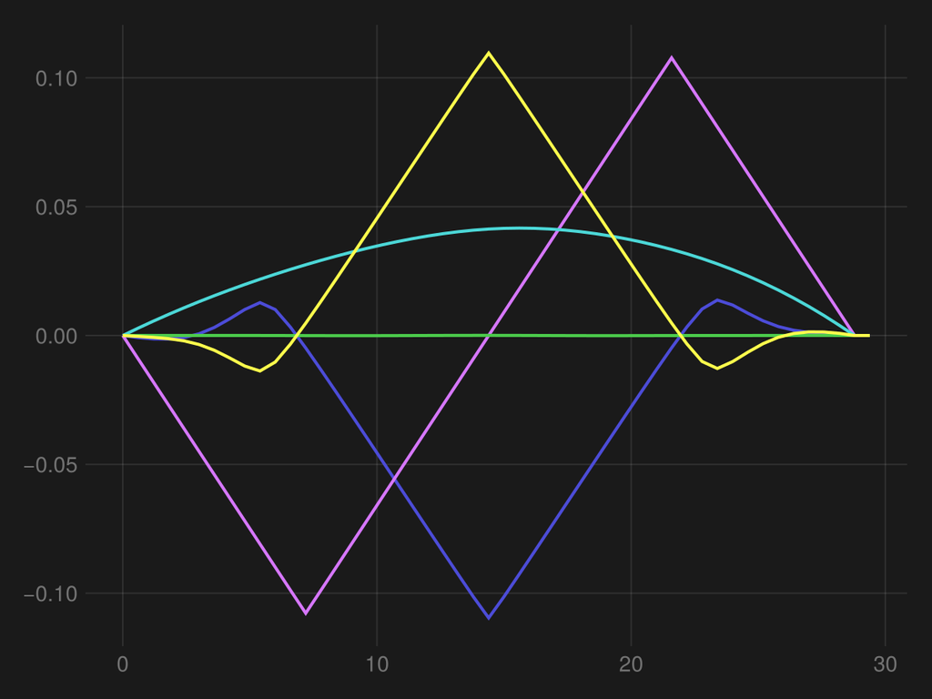

```julia
series(get_times(bound_prob.trajectory), bound_prob.trajectory.a)
```

### Minimum time controls

🚀 Piccolo can also make sure our original gate happens **as fast as possible**. We'll use the original because the bound gate we just found is already hitting its control limits.

```julia
min_prob = UnitaryMinimumTimeProblem(prob, system)

solve!(min_prob, max_iter=100, print_level=1)
```

[output not shown]

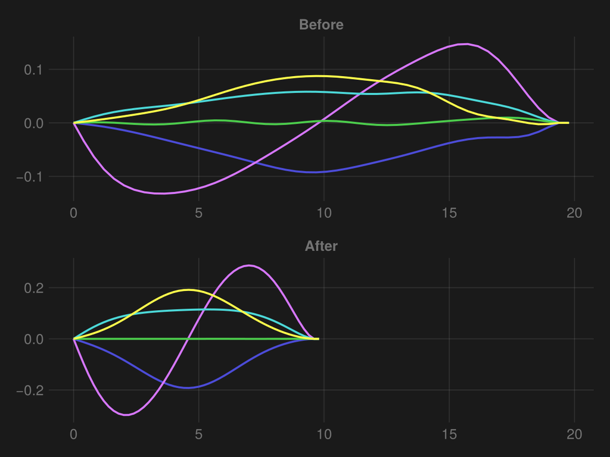

```julia
fig = Figure()
ax1 = Axis(fig[1, 1], title="Before")
ax2 = Axis(fig[2, 1], title="After")
series!(ax1, get_times(prob.trajectory), prob.trajectory.a)
series!(ax2, get_times(min_prob.trajectory), min_prob.trajectory.a)
linkxaxes!(ax1, ax2)
fig
```